# Risk Factor Analysis

## Outcome Variable

**Outcome Variable:** ever_wasted

## Predictor Variables

**Intervention Variable:** cleanck

**Adjustment Set:**

- arm
- sex
- W_mage
- meducyrs
- feducyrs
- hhwealth_quart
- W_nrooms
- W_nhh
- W_nchldlt5
- trth2o
- impfloor
- delta_meducyrs
- delta_feducyrs
- delta_hhwealth_quart
- delta_W_nrooms
- delta_W_nhh
- delta_W_nchldlt5
- delta_trth2o
- delta_impfloor

## Stratifying Variables

The analysis was stratified on these variable(s):

- agecat
- studyid
- country

## Data Summary

| agecat | studyid | country | cleanck | ever_wasted | n_cell | n |
| --- | --- | --- | --- | --- | --- | --- |
| 0-24 months (no birth wast) | ki0047075b-MAL-ED | PERU | 1 | 0 | 1 | 2 |
| 0-24 months (no birth wast) | ki0047075b-MAL-ED | PERU | 1 | 1 | 0 | 2 |
| 0-24 months (no birth wast) | ki0047075b-MAL-ED | PERU | 0 | 0 | 1 | 2 |
| 0-24 months (no birth wast) | ki0047075b-MAL-ED | PERU | 0 | 1 | 0 | 2 |
| 0-24 months (no birth wast) | ki0047075b-MAL-ED | SOUTH AFRICA | 1 | 0 | 2 | 3 |
| 0-24 months (no birth wast) | ki0047075b-MAL-ED | SOUTH AFRICA | 1 | 1 | 0 | 3 |
| 0-24 months (no birth wast) | ki0047075b-MAL-ED | SOUTH AFRICA | 0 | 0 | 1 | 3 |
| 0-24 months (no birth wast) | ki0047075b-MAL-ED | SOUTH AFRICA | 0 | 1 | 0 | 3 |
| 0-24 months (no birth wast) | ki1000108-CMC-V-BCS-2002 | INDIA | 1 | 0 | 104 | 368 |
| 0-24 months (no birth wast) | ki1000108-CMC-V-BCS-2002 | INDIA | 1 | 1 | 59 | 368 |
| 0-24 months (no birth wast) | ki1000108-CMC-V-BCS-2002 | INDIA | 0 | 0 | 98 | 368 |
| 0-24 months (no birth wast) | ki1000108-CMC-V-BCS-2002 | INDIA | 0 | 1 | 107 | 368 |
| 0-24 months (no birth wast) | ki1000108-IRC | INDIA | 1 | 0 | 107 | 399 |
| 0-24 months (no birth wast) | ki1000108-IRC | INDIA | 1 | 1 | 123 | 399 |
| 0-24 months (no birth wast) | ki1000108-IRC | INDIA | 0 | 0 | 84 | 399 |
| 0-24 months (no birth wast) | ki1000108-IRC | INDIA | 0 | 1 | 85 | 399 |
| 0-24 months (no birth wast) | ki1017093b-PROVIDE | BANGLADESH | 1 | 0 | 471 | 687 |
| 0-24 months (no birth wast) | ki1017093b-PROVIDE | BANGLADESH | 1 | 1 | 90 | 687 |
| 0-24 months (no birth wast) | ki1017093b-PROVIDE | BANGLADESH | 0 | 0 | 94 | 687 |
| 0-24 months (no birth wast) | ki1017093b-PROVIDE | BANGLADESH | 0 | 1 | 32 | 687 |
| 0-24 months (no birth wast) | ki1017093c-NIH-Crypto | BANGLADESH | 1 | 0 | 319 | 575 |
| 0-24 months (no birth wast) | ki1017093c-NIH-Crypto | BANGLADESH | 1 | 1 | 39 | 575 |
| 0-24 months (no birth wast) | ki1017093c-NIH-Crypto | BANGLADESH | 0 | 0 | 181 | 575 |
| 0-24 months (no birth wast) | ki1017093c-NIH-Crypto | BANGLADESH | 0 | 1 | 36 | 575 |
| 0-24 months (no birth wast) | ki1113344-GMS-Nepal | NEPAL | 1 | 0 | 6 | 525 |
| 0-24 months (no birth wast) | ki1113344-GMS-Nepal | NEPAL | 1 | 1 | 3 | 525 |
| 0-24 months (no birth wast) | ki1113344-GMS-Nepal | NEPAL | 0 | 0 | 235 | 525 |
| 0-24 months (no birth wast) | ki1113344-GMS-Nepal | NEPAL | 0 | 1 | 281 | 525 |
| 0-6 months (no birth wast) | ki0047075b-MAL-ED | PERU | 1 | 0 | 1 | 2 |
| 0-6 months (no birth wast) | ki0047075b-MAL-ED | PERU | 1 | 1 | 0 | 2 |
| 0-6 months (no birth wast) | ki0047075b-MAL-ED | PERU | 0 | 0 | 1 | 2 |
| 0-6 months (no birth wast) | ki0047075b-MAL-ED | PERU | 0 | 1 | 0 | 2 |
| 0-6 months (no birth wast) | ki0047075b-MAL-ED | SOUTH AFRICA | 1 | 0 | 2 | 3 |
| 0-6 months (no birth wast) | ki0047075b-MAL-ED | SOUTH AFRICA | 1 | 1 | 0 | 3 |
| 0-6 months (no birth wast) | ki0047075b-MAL-ED | SOUTH AFRICA | 0 | 0 | 1 | 3 |
| 0-6 months (no birth wast) | ki0047075b-MAL-ED | SOUTH AFRICA | 0 | 1 | 0 | 3 |
| 0-6 months (no birth wast) | ki1000108-CMC-V-BCS-2002 | INDIA | 1 | 0 | 117 | 350 |
| 0-6 months (no birth wast) | ki1000108-CMC-V-BCS-2002 | INDIA | 1 | 1 | 40 | 350 |
| 0-6 months (no birth wast) | ki1000108-CMC-V-BCS-2002 | INDIA | 0 | 0 | 125 | 350 |
| 0-6 months (no birth wast) | ki1000108-CMC-V-BCS-2002 | INDIA | 0 | 1 | 68 | 350 |
| 0-6 months (no birth wast) | ki1000108-IRC | INDIA | 1 | 0 | 136 | 381 |
| 0-6 months (no birth wast) | ki1000108-IRC | INDIA | 1 | 1 | 86 | 381 |
| 0-6 months (no birth wast) | ki1000108-IRC | INDIA | 0 | 0 | 115 | 381 |
| 0-6 months (no birth wast) | ki1000108-IRC | INDIA | 0 | 1 | 44 | 381 |
| 0-6 months (no birth wast) | ki1017093b-PROVIDE | BANGLADESH | 1 | 0 | 531 | 683 |
| 0-6 months (no birth wast) | ki1017093b-PROVIDE | BANGLADESH | 1 | 1 | 26 | 683 |
| 0-6 months (no birth wast) | ki1017093b-PROVIDE | BANGLADESH | 0 | 0 | 116 | 683 |
| 0-6 months (no birth wast) | ki1017093b-PROVIDE | BANGLADESH | 0 | 1 | 10 | 683 |
| 0-6 months (no birth wast) | ki1017093c-NIH-Crypto | BANGLADESH | 1 | 0 | 351 | 572 |
| 0-6 months (no birth wast) | ki1017093c-NIH-Crypto | BANGLADESH | 1 | 1 | 4 | 572 |
| 0-6 months (no birth wast) | ki1017093c-NIH-Crypto | BANGLADESH | 0 | 0 | 208 | 572 |
| 0-6 months (no birth wast) | ki1017093c-NIH-Crypto | BANGLADESH | 0 | 1 | 9 | 572 |
| 0-6 months (no birth wast) | ki1113344-GMS-Nepal | NEPAL | 1 | 0 | 6 | 506 |
| 0-6 months (no birth wast) | ki1113344-GMS-Nepal | NEPAL | 1 | 1 | 2 | 506 |
| 0-6 months (no birth wast) | ki1113344-GMS-Nepal | NEPAL | 0 | 0 | 425 | 506 |
| 0-6 months (no birth wast) | ki1113344-GMS-Nepal | NEPAL | 0 | 1 | 73 | 506 |
| 6-24 months | ki0047075b-MAL-ED | SOUTH AFRICA | 1 | 0 | 1 | 1 |
| 6-24 months | ki0047075b-MAL-ED | SOUTH AFRICA | 1 | 1 | 0 | 1 |
| 6-24 months | ki0047075b-MAL-ED | SOUTH AFRICA | 0 | 0 | 0 | 1 |
| 6-24 months | ki0047075b-MAL-ED | SOUTH AFRICA | 0 | 1 | 0 | 1 |
| 6-24 months | ki1000108-CMC-V-BCS-2002 | INDIA | 1 | 0 | 128 | 373 |
| 6-24 months | ki1000108-CMC-V-BCS-2002 | INDIA | 1 | 1 | 35 | 373 |
| 6-24 months | ki1000108-CMC-V-BCS-2002 | INDIA | 0 | 0 | 146 | 373 |
| 6-24 months | ki1000108-CMC-V-BCS-2002 | INDIA | 0 | 1 | 64 | 373 |
| 6-24 months | ki1000108-IRC | INDIA | 1 | 0 | 166 | 400 |
| 6-24 months | ki1000108-IRC | INDIA | 1 | 1 | 65 | 400 |
| 6-24 months | ki1000108-IRC | INDIA | 0 | 0 | 110 | 400 |
| 6-24 months | ki1000108-IRC | INDIA | 0 | 1 | 59 | 400 |
| 6-24 months | ki1017093b-PROVIDE | BANGLADESH | 1 | 0 | 437 | 615 |
| 6-24 months | ki1017093b-PROVIDE | BANGLADESH | 1 | 1 | 71 | 615 |
| 6-24 months | ki1017093b-PROVIDE | BANGLADESH | 0 | 0 | 79 | 615 |
| 6-24 months | ki1017093b-PROVIDE | BANGLADESH | 0 | 1 | 28 | 615 |
| 6-24 months | ki1017093c-NIH-Crypto | BANGLADESH | 1 | 0 | 306 | 559 |
| 6-24 months | ki1017093c-NIH-Crypto | BANGLADESH | 1 | 1 | 37 | 559 |
| 6-24 months | ki1017093c-NIH-Crypto | BANGLADESH | 0 | 0 | 186 | 559 |
| 6-24 months | ki1017093c-NIH-Crypto | BANGLADESH | 0 | 1 | 30 | 559 |
| 6-24 months | ki1113344-GMS-Nepal | NEPAL | 1 | 0 | 6 | 529 |
| 6-24 months | ki1113344-GMS-Nepal | NEPAL | 1 | 1 | 2 | 529 |
| 6-24 months | ki1113344-GMS-Nepal | NEPAL | 0 | 0 | 269 | 529 |
| 6-24 months | ki1113344-GMS-Nepal | NEPAL | 0 | 1 | 252 | 529 |

The following strata were considered:

- agecat: 0-24 months (no birth wast), studyid: ki0047075b-MAL-ED, country: PERU
- agecat: 0-24 months (no birth wast), studyid: ki0047075b-MAL-ED, country: SOUTH AFRICA
- agecat: 0-24 months (no birth wast), studyid: ki1000108-CMC-V-BCS-2002, country: INDIA
- agecat: 0-24 months (no birth wast), studyid: ki1000108-IRC, country: INDIA
- agecat: 0-24 months (no birth wast), studyid: ki1017093b-PROVIDE, country: BANGLADESH
- agecat: 0-24 months (no birth wast), studyid: ki1017093c-NIH-Crypto, country: BANGLADESH
- agecat: 0-24 months (no birth wast), studyid: ki1113344-GMS-Nepal, country: NEPAL
- agecat: 0-6 months (no birth wast), studyid: ki0047075b-MAL-ED, country: PERU
- agecat: 0-6 months (no birth wast), studyid: ki0047075b-MAL-ED, country: SOUTH AFRICA
- agecat: 0-6 months (no birth wast), studyid: ki1000108-CMC-V-BCS-2002, country: INDIA
- agecat: 0-6 months (no birth wast), studyid: ki1000108-IRC, country: INDIA
- agecat: 0-6 months (no birth wast), studyid: ki1017093b-PROVIDE, country: BANGLADESH
- agecat: 0-6 months (no birth wast), studyid: ki1017093c-NIH-Crypto, country: BANGLADESH
- agecat: 0-6 months (no birth wast), studyid: ki1113344-GMS-Nepal, country: NEPAL
- agecat: 6-24 months, studyid: ki0047075b-MAL-ED, country: SOUTH AFRICA
- agecat: 6-24 months, studyid: ki1000108-CMC-V-BCS-2002, country: INDIA
- agecat: 6-24 months, studyid: ki1000108-IRC, country: INDIA
- agecat: 6-24 months, studyid: ki1017093b-PROVIDE, country: BANGLADESH
- agecat: 6-24 months, studyid: ki1017093c-NIH-Crypto, country: BANGLADESH
- agecat: 6-24 months, studyid: ki1113344-GMS-Nepal, country: NEPAL

### Dropped Strata

Some strata were dropped due to rare outcomes:

- agecat: 0-24 months (no birth wast), studyid: ki0047075b-MAL-ED, country: PERU
- agecat: 0-24 months (no birth wast), studyid: ki0047075b-MAL-ED, country: SOUTH AFRICA
- agecat: 0-24 months (no birth wast), studyid: ki1113344-GMS-Nepal, country: NEPAL
- agecat: 0-6 months (no birth wast), studyid: ki0047075b-MAL-ED, country: PERU
- agecat: 0-6 months (no birth wast), studyid: ki0047075b-MAL-ED, country: SOUTH AFRICA
- agecat: 0-6 months (no birth wast), studyid: ki1017093c-NIH-Crypto, country: BANGLADESH
- agecat: 0-6 months (no birth wast), studyid: ki1113344-GMS-Nepal, country: NEPAL
- agecat: 6-24 months, studyid: ki0047075b-MAL-ED, country: SOUTH AFRICA
- agecat: 6-24 months, studyid: ki1113344-GMS-Nepal, country: NEPAL

## Methods Detail

We’re interested in the causal parameters $E[Y_a]$ for all values of $a \in \mathcal{A}$. These parameters represent the mean outcome if, possibly contrary to fact, we intervened to set all units to have $A=a$. Under the randomization and positivity assumptions, these are identified by the statistical parameters $\psi_a=E_W[E_{Y|A,W}(Y|A=a,W)]$. In addition, we’re interested in the mean of $Y$, $E[Y]$ under no intervention (the observed mean). We will estimate these parameters by using SuperLearner to fit the relevant likelihood factors – $E_{Y|A,W}(Y|A=a,W)$ and $p(A=a|W)$, and then updating our likelihood fit using a joint TMLE.

For unadjusted analyses ($W=\{\}$), initial likelihoods were estimated using Lrnr_glm to estimate the simple $E(Y|A)$ and Lrnr_mean to estimate $p(A)$. For adjusted analyses, a small library containing Lrnr_glmnet, Lrnr_xgboost, and Lrnr_mean was used.

Having estimated these parameters, we will then use the delta method to estimate relative risks and attributable risks relative to a prespecified baseline level of $A$.

# Results Detail

## Results Plots

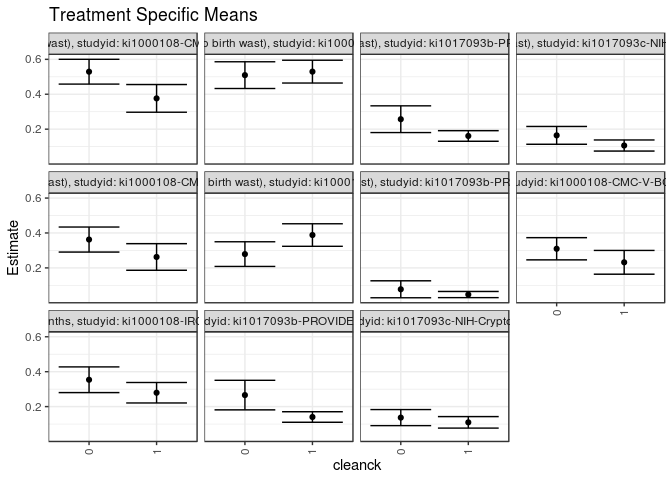

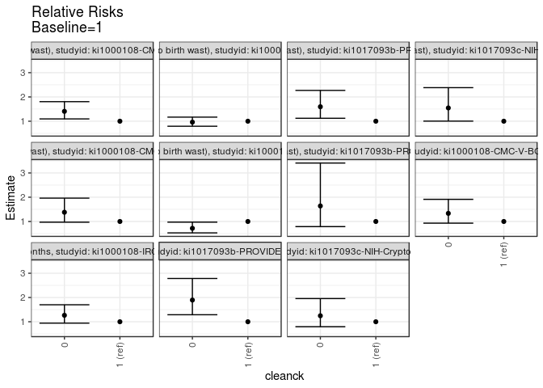

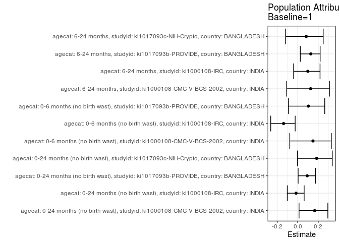

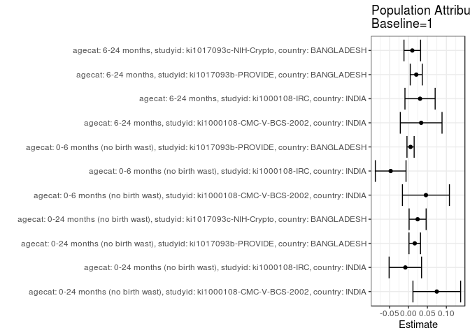

## Results Table

### Parameter: TSM

| agecat | studyid | country | intervention_level | baseline_level | estimate | ci_lower | ci_upper |
| --- | --- | --- | --- | --- | --- | --- | --- |
| 0-24 months (no birth wast) | ki1000108-CMC-V-BCS-2002 | INDIA | 1 | NA | 0.3763855 | 0.2970575 | 0.4557135 |
| 0-24 months (no birth wast) | ki1000108-CMC-V-BCS-2002 | INDIA | 0 | NA | 0.5292472 | 0.4581724 | 0.6003221 |
| 0-24 months (no birth wast) | ki1000108-IRC | INDIA | 1 | NA | 0.5296023 | 0.4642031 | 0.5950015 |
| 0-24 months (no birth wast) | ki1000108-IRC | INDIA | 0 | NA | 0.5095508 | 0.4328939 | 0.5862078 |
| 0-24 months (no birth wast) | ki1017093b-PROVIDE | BANGLADESH | 1 | NA | 0.1610594 | 0.1306833 | 0.1914355 |
| 0-24 months (no birth wast) | ki1017093b-PROVIDE | BANGLADESH | 0 | NA | 0.2570235 | 0.1804755 | 0.3335714 |
| 0-24 months (no birth wast) | ki1017093c-NIH-Crypto | BANGLADESH | 1 | NA | 0.1063237 | 0.0744902 | 0.1381572 |
| 0-24 months (no birth wast) | ki1017093c-NIH-Crypto | BANGLADESH | 0 | NA | 0.1644844 | 0.1135044 | 0.2154645 |
| 0-6 months (no birth wast) | ki1000108-CMC-V-BCS-2002 | INDIA | 1 | NA | 0.2625340 | 0.1863316 | 0.3387363 |
| 0-6 months (no birth wast) | ki1000108-CMC-V-BCS-2002 | INDIA | 0 | NA | 0.3623690 | 0.2905753 | 0.4341626 |
| 0-6 months (no birth wast) | ki1000108-IRC | INDIA | 1 | NA | 0.3882157 | 0.3236102 | 0.4528211 |
| 0-6 months (no birth wast) | ki1000108-IRC | INDIA | 0 | NA | 0.2789486 | 0.2082771 | 0.3496201 |
| 0-6 months (no birth wast) | ki1017093b-PROVIDE | BANGLADESH | 1 | NA | 0.0472254 | 0.0295919 | 0.0648589 |
| 0-6 months (no birth wast) | ki1017093b-PROVIDE | BANGLADESH | 0 | NA | 0.0774450 | 0.0288351 | 0.1260549 |
| 6-24 months | ki1000108-CMC-V-BCS-2002 | INDIA | 1 | NA | 0.2319315 | 0.1638430 | 0.3000200 |
| 6-24 months | ki1000108-CMC-V-BCS-2002 | INDIA | 0 | NA | 0.3095213 | 0.2458783 | 0.3731644 |
| 6-24 months | ki1000108-IRC | INDIA | 1 | NA | 0.2794640 | 0.2207946 | 0.3381333 |
| 6-24 months | ki1000108-IRC | INDIA | 0 | NA | 0.3538310 | 0.2802850 | 0.4273771 |
| 6-24 months | ki1017093b-PROVIDE | BANGLADESH | 1 | NA | 0.1404273 | 0.1102584 | 0.1705963 |
| 6-24 months | ki1017093b-PROVIDE | BANGLADESH | 0 | NA | 0.2660004 | 0.1812505 | 0.3507504 |
| 6-24 months | ki1017093c-NIH-Crypto | BANGLADESH | 1 | NA | 0.1098123 | 0.0768906 | 0.1427340 |
| 6-24 months | ki1017093c-NIH-Crypto | BANGLADESH | 0 | NA | 0.1369246 | 0.0909386 | 0.1829106 |

### Parameter: E(Y)

| agecat | studyid | country | intervention_level | baseline_level | estimate | ci_lower | ci_upper |
| --- | --- | --- | --- | --- | --- | --- | --- |
| 0-24 months (no birth wast) | ki1000108-CMC-V-BCS-2002 | INDIA | NA | NA | 0.4510870 | 0.4001777 | 0.5019962 |
| 0-24 months (no birth wast) | ki1000108-IRC | INDIA | NA | NA | 0.5213033 | 0.4722258 | 0.5703807 |
| 0-24 months (no birth wast) | ki1017093b-PROVIDE | BANGLADESH | NA | NA | 0.1775837 | 0.1489858 | 0.2061816 |
| 0-24 months (no birth wast) | ki1017093c-NIH-Crypto | BANGLADESH | NA | NA | 0.1304348 | 0.1028836 | 0.1579859 |
| 0-6 months (no birth wast) | ki1000108-CMC-V-BCS-2002 | INDIA | NA | NA | 0.3085714 | 0.2601110 | 0.3570318 |
| 0-6 months (no birth wast) | ki1000108-IRC | INDIA | NA | NA | 0.3412073 | 0.2935379 | 0.3888768 |
| 0-6 months (no birth wast) | ki1017093b-PROVIDE | BANGLADESH | NA | NA | 0.0527086 | 0.0359384 | 0.0694789 |
| 6-24 months | ki1000108-CMC-V-BCS-2002 | INDIA | NA | NA | 0.2654155 | 0.2205451 | 0.3102860 |
| 6-24 months | ki1000108-IRC | INDIA | NA | NA | 0.3100000 | 0.2646197 | 0.3553803 |
| 6-24 months | ki1017093b-PROVIDE | BANGLADESH | NA | NA | 0.1609756 | 0.1319065 | 0.1900447 |
| 6-24 months | ki1017093c-NIH-Crypto | BANGLADESH | NA | NA | 0.1198569 | 0.0929081 | 0.1468057 |

### Parameter: RR

| agecat | studyid | country | intervention_level | baseline_level | estimate | ci_lower | ci_upper |
| --- | --- | --- | --- | --- | --- | --- | --- |
| 0-24 months (no birth wast) | ki1000108-CMC-V-BCS-2002 | INDIA | 1 | 1 | 1.0000000 | 1.0000000 | 1.0000000 |
| 0-24 months (no birth wast) | ki1000108-CMC-V-BCS-2002 | INDIA | 0 | 1 | 1.4061308 | 1.0948391 | 1.8059310 |
| 0-24 months (no birth wast) | ki1000108-IRC | INDIA | 1 | 1 | 1.0000000 | 1.0000000 | 1.0000000 |
| 0-24 months (no birth wast) | ki1000108-IRC | INDIA | 0 | 1 | 0.9621386 | 0.7922334 | 1.1684824 |
| 0-24 months (no birth wast) | ki1017093b-PROVIDE | BANGLADESH | 1 | 1 | 1.0000000 | 1.0000000 | 1.0000000 |
| 0-24 months (no birth wast) | ki1017093b-PROVIDE | BANGLADESH | 0 | 1 | 1.5958306 | 1.1221023 | 2.2695573 |
| 0-24 months (no birth wast) | ki1017093c-NIH-Crypto | BANGLADESH | 1 | 1 | 1.0000000 | 1.0000000 | 1.0000000 |
| 0-24 months (no birth wast) | ki1017093c-NIH-Crypto | BANGLADESH | 0 | 1 | 1.5470159 | 1.0045219 | 2.3824848 |
| 0-6 months (no birth wast) | ki1000108-CMC-V-BCS-2002 | INDIA | 1 | 1 | 1.0000000 | 1.0000000 | 1.0000000 |
| 0-6 months (no birth wast) | ki1000108-CMC-V-BCS-2002 | INDIA | 0 | 1 | 1.3802745 | 0.9709744 | 1.9621091 |
| 0-6 months (no birth wast) | ki1000108-IRC | INDIA | 1 | 1 | 1.0000000 | 1.0000000 | 1.0000000 |
| 0-6 months (no birth wast) | ki1000108-IRC | INDIA | 0 | 1 | 0.7185404 | 0.5304589 | 0.9733087 |
| 0-6 months (no birth wast) | ki1017093b-PROVIDE | BANGLADESH | 1 | 1 | 1.0000000 | 1.0000000 | 1.0000000 |
| 0-6 months (no birth wast) | ki1017093b-PROVIDE | BANGLADESH | 0 | 1 | 1.6399014 | 0.7888613 | 3.4090614 |
| 6-24 months | ki1000108-CMC-V-BCS-2002 | INDIA | 1 | 1 | 1.0000000 | 1.0000000 | 1.0000000 |
| 6-24 months | ki1000108-CMC-V-BCS-2002 | INDIA | 0 | 1 | 1.3345380 | 0.9313016 | 1.9123683 |
| 6-24 months | ki1000108-IRC | INDIA | 1 | 1 | 1.0000000 | 1.0000000 | 1.0000000 |
| 6-24 months | ki1000108-IRC | INDIA | 0 | 1 | 1.2661061 | 0.9426195 | 1.7006063 |
| 6-24 months | ki1017093b-PROVIDE | BANGLADESH | 1 | 1 | 1.0000000 | 1.0000000 | 1.0000000 |
| 6-24 months | ki1017093b-PROVIDE | BANGLADESH | 0 | 1 | 1.8942210 | 1.2891745 | 2.7832331 |
| 6-24 months | ki1017093c-NIH-Crypto | BANGLADESH | 1 | 1 | 1.0000000 | 1.0000000 | 1.0000000 |
| 6-24 months | ki1017093c-NIH-Crypto | BANGLADESH | 0 | 1 | 1.2468969 | 0.7952578 | 1.9550287 |

### Parameter: PAR

| agecat | studyid | country | intervention_level | baseline_level | estimate | ci_lower | ci_upper |
| --- | --- | --- | --- | --- | --- | --- | --- |
| 0-24 months (no birth wast) | ki1000108-CMC-V-BCS-2002 | INDIA | 1 | NA | 0.0747015 | 0.0117839 | 0.1376191 |
| 0-24 months (no birth wast) | ki1000108-IRC | INDIA | 1 | NA | -0.0082990 | -0.0511210 | 0.0345229 |
| 0-24 months (no birth wast) | ki1017093b-PROVIDE | BANGLADESH | 1 | NA | 0.0165243 | 0.0013417 | 0.0317069 |
| 0-24 months (no birth wast) | ki1017093c-NIH-Crypto | BANGLADESH | 1 | NA | 0.0241111 | 0.0016480 | 0.0465742 |
| 0-6 months (no birth wast) | ki1000108-CMC-V-BCS-2002 | INDIA | 1 | NA | 0.0460375 | -0.0159546 | 0.1080295 |
| 0-6 months (no birth wast) | ki1000108-IRC | INDIA | 1 | NA | -0.0470083 | -0.0875372 | -0.0064795 |
| 0-6 months (no birth wast) | ki1017093b-PROVIDE | BANGLADESH | 1 | NA | 0.0054833 | -0.0039844 | 0.0149509 |
| 6-24 months | ki1000108-CMC-V-BCS-2002 | INDIA | 1 | NA | 0.0334841 | -0.0215716 | 0.0885397 |
| 6-24 months | ki1000108-IRC | INDIA | 1 | NA | 0.0305360 | -0.0093076 | 0.0703797 |
| 6-24 months | ki1017093b-PROVIDE | BANGLADESH | 1 | NA | 0.0205483 | 0.0046532 | 0.0364434 |
| 6-24 months | ki1017093c-NIH-Crypto | BANGLADESH | 1 | NA | 0.0100446 | -0.0118886 | 0.0319778 |

### Parameter: PAF

| agecat | studyid | country | intervention_level | baseline_level | estimate | ci_lower | ci_upper |
| --- | --- | --- | --- | --- | --- | --- | --- |
| 0-24 months (no birth wast) | ki1000108-CMC-V-BCS-2002 | INDIA | 1 | NA | 0.1656032 | 0.0131962 | 0.2944717 |
| 0-24 months (no birth wast) | ki1000108-IRC | INDIA | 1 | NA | -0.0159198 | -0.1014774 | 0.0629922 |
| 0-24 months (no birth wast) | ki1017093b-PROVIDE | BANGLADESH | 1 | NA | 0.0930509 | 0.0043399 | 0.1738580 |
| 0-24 months (no birth wast) | ki1017093c-NIH-Crypto | BANGLADESH | 1 | NA | 0.1848518 | -0.0025895 | 0.3372496 |
| 0-6 months (no birth wast) | ki1000108-CMC-V-BCS-2002 | INDIA | 1 | NA | 0.1491954 | -0.0772373 | 0.3280326 |
| 0-6 months (no birth wast) | ki1000108-IRC | INDIA | 1 | NA | -0.1377706 | -0.2632721 | -0.0247372 |
| 0-6 months (no birth wast) | ki1017093b-PROVIDE | BANGLADESH | 1 | NA | 0.1040297 | -0.0909272 | 0.2641464 |
| 6-24 months | ki1000108-CMC-V-BCS-2002 | INDIA | 1 | NA | 0.1261572 | -0.1071177 | 0.3102801 |
| 6-24 months | ki1000108-IRC | INDIA | 1 | NA | 0.0985033 | -0.0396294 | 0.2182827 |
| 6-24 months | ki1017093b-PROVIDE | BANGLADESH | 1 | NA | 0.1276483 | 0.0253455 | 0.2192131 |
| 6-24 months | ki1017093c-NIH-Crypto | BANGLADESH | 1 | NA | 0.0838050 | -0.1175239 | 0.2488632 |